# CENTRO UNIVERSITÁRIO 7 DE SETEMBRO

# Especialização em Ciência de Dados com Big Data, BI e Data Analytics

# Disciplina: Análise Estatística de Dados

# Professor: Prof. Dr. Marcio Mota

## Equipe:

# Questão 2 (3 pontos):

O controlador da XPTO deseja determinar a influência das variáveis mão de obra (MO) e energia elétrica (EE) nos custos totais de fabricação (CTF) de seus produtos. Para isso, fez um levantamento dos valores destas variáveis nos últimos 24 meses e os resultados são mostrados na tabela, onde XXX representa os três últimos algarismos do seu número de matrícula na UNI7 (escolha a matrícula de um dos alunos da equipe, se for o caso).

| Meses | CTF | MO | EE |
| --- | --- | --- | --- |
| 1 | 5XXX8 | 2378 | 980 |
| 2 | XXX34 | 2295 | 945 |
| 3 | 62XXX | 2450 | 930 |
| 4 | 6XXX7 | 2487 | 995 |
| 5 | 71XXX | 2390 | 985 |
| 6 | 46XXX | 2550 | 1010 |
| 7 | XXX67 | 2440 | 998 |
| 8 | 5XXX9 | 2590 | 1025 |
| 9 | 7XXX3 | 2610 | 1100 |
| 10 | 54XXX | 2575 | 1045 |
| 11 | XXX98 | 2490 | 1038 |
| 12 | XXX75 | 2580 | 1095 |
| 13 | 6XXX3 | 2395 | 1150 |
| 14 | 65XXX | 2640 | 1030 |
| 15 | 4XXX9 | 2595 | 1085 |
| 16 | XXX68 | 2720 | 1175 |
| 17 | 7XXX0 | 2690 | 1190 |
| 18 | 6XXX8 | 2565 | 1165 |
| 19 | 69XXX | 2585 | 1200 |
| 20 | XXX49 | 2615 | 1195 |
| 21 | 60XXX | 2590 | 1210 |
| 22 | 7XXX1 | 2630 | 1189 |
| 23 | 58XXX | 2680 | 1205 |
| 24 | 63XXX | 2700 | 1200 |

Faça as análises de regressão simples e múltipla e determine o modelo de previsão para os CTF em função de MO e EE. Calcule os CTF para os seguintes valores:

| Meses | MO | EE |
| --- | --- | --- |
| 25 | 2695 | 1120 |
| 26 | 2584 | 1185 |
| 27 | 2710 | 1178 |
| 28 | 2705 | 1205 |
| 29 | 2715 | 1195 |

# Solução

```python
import pandas as pd
import numpy as np
import matplotlib.pyplot as plt
import seaborn as sns
import statsmodels.api as sm
import statsmodels.formula.api as smf
from sklearn.linear_model import LinearRegression
from yellowbrick.regressor import ResidualsPlot


#
# Formatar o output das variáveis no mesmo padrão
num_format = "{:>22.10f}".format
```

```python
df = pd.read_csv('est-q2-1.csv')
print(df)
print(df.dtypes)
df_previsao = pd.read_csv('est-q2-2.csv')
print(df_previsao)
print(df_previsao.dtypes)
```

```
    Meses    CTF    MO    EE
0       1  5XXX8  2378   980
1       2  XXX34  2295   945
2       3  62XXX  2450   930
3       4  6XXX7  2487   995
4       5  71XXX  2390   985
5       6  46XXX  2550  1010
6       7  XXX67  2440   998
7       8  5XXX9  2590  1025
8       9  7XXX3  2610  1100
9      10  54XXX  2575  1045
10     11  XXX98  2490  1038
11     12  XXX75  2580  1095
12     13  6XXX3  2395  1150
13     14  65XXX  2640  1030
```

[output cut: 25 more lines]

### Substituir XXX três últimos algarismos do seu número de matrícula na UNI7

### Allan Lima: 1982782

```python
mat = '782'
df['CTF'] = df['CTF'].str.replace('XXX', mat).astype('int64')
df
```

|  | Meses | CTF | MO | EE |
| --- | --- | --- | --- | --- |
| 0 | 1 | 57828 | 2378 | 980 |
| 1 | 2 | 78234 | 2295 | 945 |
| 2 | 3 | 62782 | 2450 | 930 |
| 3 | 4 | 67827 | 2487 | 995 |
| 4 | 5 | 71782 | 2390 | 985 |
| 5 | 6 | 46782 | 2550 | 1010 |
| 6 | 7 | 78267 | 2440 | 998 |
| 7 | 8 | 57829 | 2590 | 1025 |
| 8 | 9 | 77823 | 2610 | 1100 |
| 9 | 10 | 54782 | 2575 | 1045 |
| 10 | 11 | 78298 | 2490 | 1038 |
| 11 | 12 | 78275 | 2580 | 1095 |
| 12 | 13 | 67823 | 2395 | 1150 |
| 13 | 14 | 65782 | 2640 | 1030 |
| 14 | 15 | 47829 | 2595 | 1085 |
| 15 | 16 | 78268 | 2720 | 1175 |
| 16 | 17 | 77820 | 2690 | 1190 |
| 17 | 18 | 67828 | 2565 | 1165 |
| 18 | 19 | 69782 | 2585 | 1200 |
| 19 | 20 | 78249 | 2615 | 1195 |
| 20 | 21 | 60782 | 2590 | 1210 |
| 21 | 22 | 77821 | 2630 | 1189 |
| 22 | 23 | 58782 | 2680 | 1205 |
| 23 | 24 | 63782 | 2700 | 1200 |

```
array([[<matplotlib.axes._subplots.AxesSubplot object at 0x17F76658>,
      dtype=object)
```

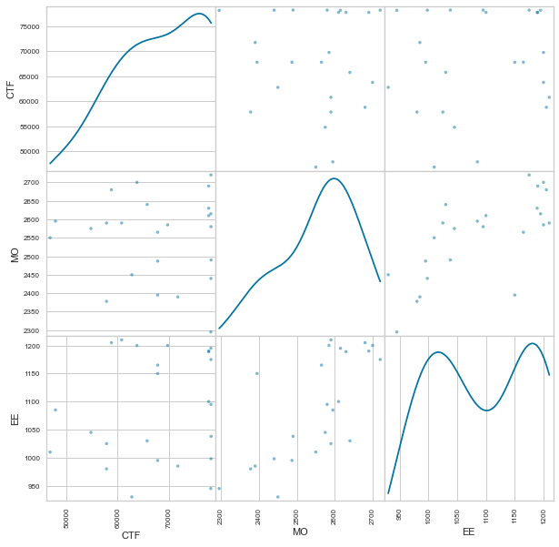

```python
# Matriz de dispersão
pd.plotting.scatter_matrix(df[['CTF', 'MO', 'EE']], diagonal='kde', figsize=(10, 10))
```

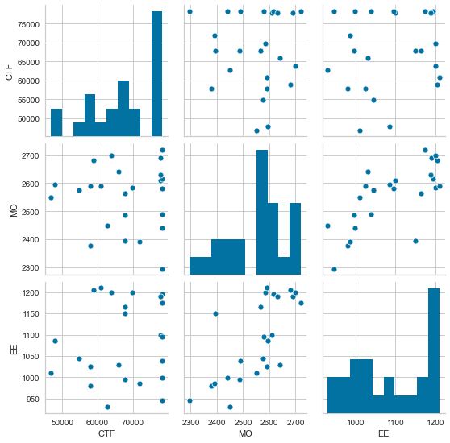

```python
sns.pairplot(df[['CTF', 'MO', 'EE']])
```

## Correlação

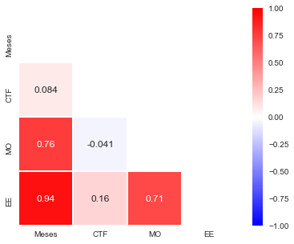

```python
correlacao = df.corr()

mask = np.zeros_like(correlacao)
mask[np.triu_indices_from(mask)] = True
f, ax = plt.subplots(figsize=(7, 5))
ax = sns.heatmap(correlacao, mask=mask, annot=True, cmap="bwr", square=True, linewidths=.5, vmin=-1, vmax=1)
```

## Análise de Regressão Simples MO x CTF

- Variável Independente: $X = MO$
- Variável Dependente: $Y = CTF$
- Modelo:
  - $y = a_1 + b_1 x_1 + \varepsilon$
  - $CTF = a_1 + b_1 MO + \varepsilon$

```python
# Variável Independente
X1str = 'MO'
# Variável Dependente
Ystr = 'CTF'
# Selecionando Y e X
X1 = df[X1str].values
Y = df[Ystr].values

# Correlação
correlacao = np.corrcoef(X1, Y)
print(f"CORRELAÇÃO     (R):", num_format(correlacao[0,1]))
# Correlação com outro método
correlacao2 = df[[Ystr,X1str]].corr()[Ystr][X1str]
print(f"CORRELAÇÃO     (R):", num_format(correlacao2))

# Modelo de Regressão Linear
modelo = LinearRegression()
X1 = X1.reshape(-1,1)
modelo.fit(X1, Y)

# Coeficiente de Determinação
coef_determinacao = modelo.score(X1, Y)
print(f"DETERMINAÇÃO (R^2):", num_format(coef_determinacao))

# Coeficientes Angular (a) e Linear (b)
a = modelo.intercept_
b = modelo.coef_[0]
print(f"INTERCEPTAÇÃO  (a):", num_format(a))
print(f"INCLINAÇÃO     (b):", num_format(b))

# Somatório dos resíduos
print(f"RESÍDUOS          :", num_format(modelo._residues))

# Previsão
x = np.array(df_previsao[X1str].values)
x = x.reshape(-1,1)
previsao = modelo.predict(np.array(x))
for idx, p in np.ndenumerate(previsao):
    print(f"PREVISÃO-{idx}     :", num_format(p))
```

```
CORRELAÇÃO     (R):          -0.0409251476
CORRELAÇÃO     (R):          -0.0409251476
DETERMINAÇÃO (R^2):           0.0016748677
INTERCEPTAÇÃO  (a):       77100.3931378766
INCLINAÇÃO     (b):          -3.6798242212
RESÍDUOS          :  2358940599.1765027046
PREVISÃO-(0,)     :       67183.2668616216
PREVISÃO-(1,)     :       67591.7273501797
PREVISÃO-(2,)     :       67128.0694983029
PREVISÃO-(3,)     :       67146.4686194091
PREVISÃO-(4,)     :       67109.6703771967
```

```python
df['CTF-MO-Previsto'] = modelo.predict(X1)
df['CTF-MO-Diferenca'] = df['CTF'] - df['CTF-MO-Previsto']
df
```

|  | Meses | CTF | MO | EE | CTF-MO-Previsto | CTF-MO-Diferenca |
| --- | --- | --- | --- | --- | --- | --- |
| 0 | 1 | 57828 | 2378 | 980 | 68349.771140 | -10521.771140 |
| 1 | 2 | 78234 | 2295 | 945 | 68655.196550 | 9578.803450 |
| 2 | 3 | 62782 | 2450 | 930 | 68084.823796 | -5302.823796 |
| 3 | 4 | 67827 | 2487 | 995 | 67948.670300 | -121.670300 |
| 4 | 5 | 71782 | 2390 | 985 | 68305.613249 | 3476.386751 |
| 5 | 6 | 46782 | 2550 | 1010 | 67716.841374 | -20934.841374 |
| 6 | 7 | 78267 | 2440 | 998 | 68121.622038 | 10145.377962 |
| 7 | 8 | 57829 | 2590 | 1025 | 67569.648405 | -9740.648405 |
| 8 | 9 | 77823 | 2610 | 1100 | 67496.051920 | 10326.948080 |
| 9 | 10 | 54782 | 2575 | 1045 | 67624.845768 | -12842.845768 |
| 10 | 11 | 78298 | 2490 | 1038 | 67937.630827 | 10360.369173 |
| 11 | 12 | 78275 | 2580 | 1095 | 67606.446647 | 10668.553353 |
| 12 | 13 | 67823 | 2395 | 1150 | 68287.214128 | -464.214128 |
| 13 | 14 | 65782 | 2640 | 1030 | 67385.657194 | -1603.657194 |
| 14 | 15 | 47829 | 2595 | 1085 | 67551.249284 | -19722.249284 |
| 15 | 16 | 78268 | 2720 | 1175 | 67091.271256 | 11176.728744 |
| 16 | 17 | 77820 | 2690 | 1190 | 67201.665983 | 10618.334017 |
| 17 | 18 | 67828 | 2565 | 1165 | 67661.644010 | 166.355990 |
| 18 | 19 | 69782 | 2585 | 1200 | 67588.047526 | 2193.952474 |
| 19 | 20 | 78249 | 2615 | 1195 | 67477.652799 | 10771.347201 |
| 20 | 21 | 60782 | 2590 | 1210 | 67569.648405 | -6787.648405 |
| 21 | 22 | 77821 | 2630 | 1189 | 67422.455436 | 10398.544564 |
| 22 | 23 | 58782 | 2680 | 1205 | 67238.464225 | -8456.464225 |
| 23 | 24 | 63782 | 2700 | 1200 | 67164.867741 | -3382.867741 |

```python
# Modelo de Regressão Linear
formula = ' ~ '.join([Ystr, X1str])
modelo_ajustado = smf.ols(formula=formula, data=df)
modelo_treinado = modelo_ajustado.fit()
#
print(f"R^2               :", num_format(modelo_treinado.rsquared))
print(f"R^2 AJUSTADO      :", num_format(modelo_treinado.rsquared_adj))
print(f"F value           :", num_format(modelo_treinado.f_pvalue))
print(f"P value           :", num_format(modelo_treinado.pvalues[1]))
a = modelo_treinado.params['Intercept']
b = modelo_treinado.params['MO']
print(f"INTERCEPTAÇÃO  (a):", num_format(a))
print(f"INCLINAÇÃO-MO  (b):", num_format(b))

print('\n' + '='*80 + '\n')

modelo_treinado.summary()
```

```
R^2               :           0.0016748677
R^2 AJUSTADO      :          -0.0437035474
F value           :           0.8494129018
P value           :           0.8494129018
INTERCEPTAÇÃO  (a):       77100.3931378771
INCLINAÇÃO-MO  (b):          -3.6798242212

================================================================================
```

OLS Regression Results

| Dep. Variable: | CTF | R-squared: | 0.002 |
| --- | --- | --- | --- |
| Model: | OLS | Adj. R-squared: | -0.044 |
| Method: | Least Squares | F-statistic: | 0.03691 |
| Date: | Sun, 31 May 2020 | Prob (F-statistic): | 0.849 |
| Time: | 23:40:56 | Log-Likelihood: | -254.90 |
| No. Observations: | 24 | AIC: | 513.8 |
| Df Residuals: | 22 | BIC: | 516.1 |
| Df Model: | 1 |  |  |
| Covariance Type: | nonrobust |  |  |

|  | coef | std err | t | P>\|t\| | [0.025 | 0.975] |
| --- | --- | --- | --- | --- | --- | --- |
| Intercept | 7.71e+04 | 4.89e+04 | 1.576 | 0.129 | -2.44e+04 | 1.79e+05 |
| MO | -3.6798 | 19.154 | -0.192 | 0.849 | -43.403 | 36.043 |

| Omnibus: | 2.050 | Durbin-Watson: | 2.832 |
| --- | --- | --- | --- |
| Prob(Omnibus): | 0.359 | Jarque-Bera (JB): | 1.668 |
| Skew: | -0.504 | Prob(JB): | 0.434 |
| Kurtosis: | 2.193 | Cond. No. | 5.91e+04 |

Warnings:  
[1] Standard Errors assume that the covariance matrix of the errors is correctly specified.  
[2] The condition number is large, 5.91e+04. This might indicate that there are  
strong multicollinearity or other numerical problems.

## Gráfico de Dispersão MO x CTF

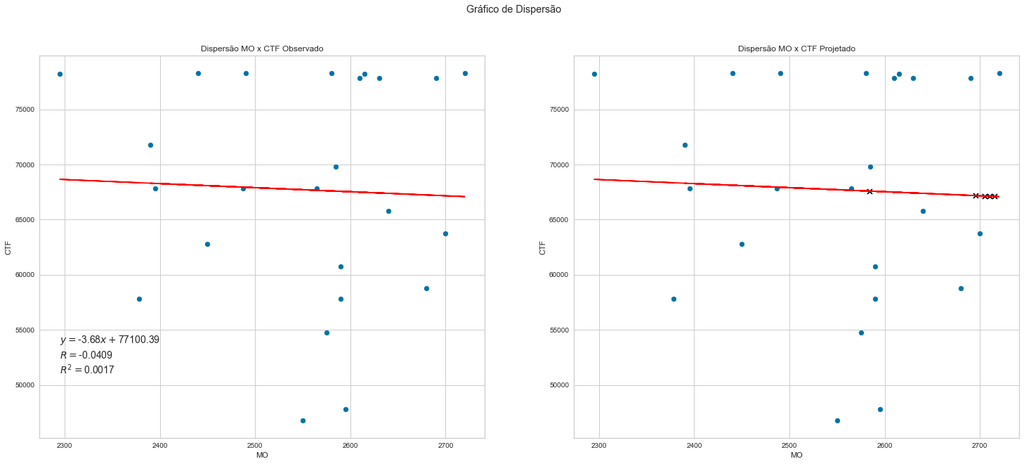

```python
fig, (ax1, ax2) = plt.subplots(1, 2, figsize=(25, 10))
fig.suptitle('Gráfico de Dispersão')
ax1.scatter(X1, Y)
ax1.plot(X1, modelo.predict(X1), color='red')
ax1.set_title('Dispersão MO x CTF Observado')
ax1.set_xlabel(X1str)
ax1.set_ylabel(Ystr)
ax1.text(X1.min(), Y.min()*1.15, r'$y = ${:.2f}$x+${:.2f}'.format(b,a), fontsize=14)
ax1.text(X1.min(), Y.min()*1.12, r'$R = ${:.4f}'.format(correlacao[0,1]), fontsize=14)
ax1.text(X1.min(), Y.min()*1.09, r'$R^2 = ${:.4f}'.format(coef_determinacao), fontsize=14)
ax2.set_title('Dispersão MO x CTF Projetado')
ax2.set_xlabel(X1str)
ax2.set_ylabel(Ystr)
ax2.scatter(X1, Y)
ax2.plot(X1, modelo.predict(X1), color='red')
ax2.scatter(x, previsao, color='black', marker='x')
```

### Análise dos Resultados MO x CTF

Analisando-se o relatório de resumos de resultados para o modelo $CTF = a + b_1 MO + \varepsilon$, tem-se que:

- $R^2 = 0,001674$: indica que não existe correlação linear ($R^2 \approx 0$) entre as variáveis, pois $0,1674\%$ da variação de $CTF$ são explicados pela variação de $MO$;
- $P_{value} = 0,8494 (84,94\%)$ : indica que o relacionamento linear entre as variáveis $CTF$ e $MO$ não é significativo, pois não é menor que $5\%$.
- O modelo proposto é $CTF = 77100,39 - 3,68 MO$
- Conclui-se que o modelo proposto é **inadequado** para prever o comportamento da variável dependente $CTF$.

## Análise de Regressão Simples EE x CTF

- Variável Independente: $X = EE$
- Variável Dependente: $Y = CTF$
- Modelo:
  - $y = a_2 + b_2 x_2 + \varepsilon$
  - $CTF = a_2 + b_2 EE + \varepsilon$

```python
# Variável Independente
X2str = 'EE'
# Variável Dependente
Ystr = 'CTF'
X2 = df[X2str].values
Y = df[Ystr].values

# Correlação
correlacao = np.corrcoef(X2, Y)
print(f"CORRELAÇÃO     (R):", num_format(correlacao[0,1]))
# Correlação com outro método
correlacao2 = df[[Ystr,X2str]].corr()[Ystr][X2str]
print(df[[Ystr,X2str]].corr())
print(f"CORRELAÇÃO     (R):", num_format(correlacao2))

# Modelo de Regressão Linear
modelo = LinearRegression()
X2 = X2.reshape(-1,1)
modelo.fit(X2, Y)

# Coeficiente de Determinação
coef_determinacao = modelo.score(X2, Y)
print(f"DETERMINAÇÃO (R^2):", num_format(coef_determinacao))

# Coeficientes Angular (a) e Linear (b)
a = modelo.intercept_
b = modelo.coef_[0]
print(f"INTERCEPTAÇÃO  (a):", num_format(a))
print(f"INCLINAÇÃO     (b):", num_format(b))

# Somatório dos resíduos
print(f"RESÍDUOS          :", num_format(modelo._residues))

# Previsão
x = np.array(df_previsao[X2str].values)
x = x.reshape(-1,1)
previsao = modelo.predict(np.array(x))
for idx, p in np.ndenumerate(previsao):
    print(f"PREVISÃO-{idx}     :", num_format(p))
```

```
CORRELAÇÃO     (R):           0.1645682388
          CTF        EE
CTF  1.000000  0.164568
EE   0.164568  1.000000
CORRELAÇÃO     (R):           0.1645682388
DETERMINAÇÃO (R^2):           0.0270827052
INTERCEPTAÇÃO  (a):       48487.1513665822
INCLINAÇÃO     (b):          17.6497845142
RESÍDUOS          :  2298904467.1137948036
PREVISÃO-(0,)     :       68254.9100225221
PREVISÃO-(1,)     :       69402.1460159472
PREVISÃO-(2,)     :       69278.5975243476
PREVISÃO-(3,)     :       69755.1417062319
PREVISÃO-(4,)     :       69578.6438610896
```

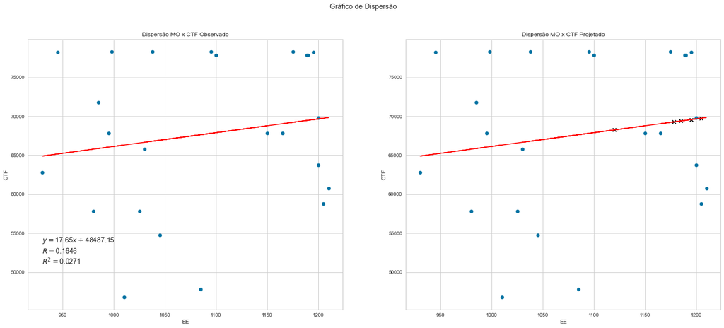

```python
fig, (ax1, ax2) = plt.subplots(1, 2, figsize=(25, 10))
fig.suptitle('Gráfico de Dispersão')
ax1.scatter(X2, Y)
ax1.plot(X2, modelo.predict(X2), color='red')
ax1.set_title('Dispersão MO x CTF Observado')
ax1.set_xlabel(X2str)
ax1.set_ylabel(Ystr)
ax1.text(X2.min(), Y.min()*1.15, r'$y = ${:.2f}$x+${:.2f}'.format(b,a), fontsize=14)
ax1.text(X2.min(), Y.min()*1.12, r'$R = ${:.4f}'.format(correlacao[0,1]), fontsize=14)
ax1.text(X2.min(), Y.min()*1.09, r'$R^2 = ${:.4f}'.format(coef_determinacao), fontsize=14)
ax2.set_title('Dispersão MO x CTF Projetado')
ax2.set_xlabel(X2str)
ax2.set_ylabel(Ystr)
ax2.scatter(X2, Y)
ax2.plot(X2, modelo.predict(X2), color='red')
ax2.scatter(x, previsao, color='black', marker='x')
```

```python
# Modelo de Regressão Linear
formula = ' ~ '.join([Ystr, X2str])
modelo_ajustado = smf.ols(formula=formula, data=df)
modelo_treinado = modelo_ajustado.fit()
print(f"R^2          :", num_format(modelo_treinado.rsquared))
print(f"R^2 AJUSTADO :", num_format(modelo_treinado.rsquared_adj))
print(f"F value      :", num_format(modelo_treinado.f_pvalue))
print(f"P value      :", num_format(modelo_treinado.pvalues[1]))
print('\n' + '='*80 + '\n')
modelo_treinado.summary()
```

```
R^2          :           0.0270827052
R^2 AJUSTADO :          -0.0171408082
F value      :           0.4422261740
P value      :           0.4422261740

================================================================================
```

OLS Regression Results

| Dep. Variable: | CTF | R-squared: | 0.027 |
| --- | --- | --- | --- |
| Model: | OLS | Adj. R-squared: | -0.017 |
| Method: | Least Squares | F-statistic: | 0.6124 |
| Date: | Sun, 31 May 2020 | Prob (F-statistic): | 0.442 |
| Time: | 23:40:56 | Log-Likelihood: | -254.59 |
| No. Observations: | 24 | AIC: | 513.2 |
| Df Residuals: | 22 | BIC: | 515.5 |
| Df Model: | 1 |  |  |
| Covariance Type: | nonrobust |  |  |

|  | coef | std err | t | P>\|t\| | [0.025 | 0.975] |
| --- | --- | --- | --- | --- | --- | --- |
| Intercept | 4.849e+04 | 2.47e+04 | 1.967 | 0.062 | -2640.718 | 9.96e+04 |
| EE | 17.6498 | 22.554 | 0.783 | 0.442 | -29.124 | 64.424 |

| Omnibus: | 2.075 | Durbin-Watson: | 2.912 |
| --- | --- | --- | --- |
| Prob(Omnibus): | 0.354 | Jarque-Bera (JB): | 1.569 |
| Skew: | -0.446 | Prob(JB): | 0.456 |
| Kurtosis: | 2.121 | Cond. No. | 1.29e+04 |

Warnings:  
[1] Standard Errors assume that the covariance matrix of the errors is correctly specified.  
[2] The condition number is large, 1.29e+04. This might indicate that there are  
strong multicollinearity or other numerical problems.

### Análise dos Resultados EE x CTF

Analisando-se o relatório de resumos de resultados para o modelo $CTF = a + b_2 EE + \varepsilon$, tem-se que:

- $R^2 = 0,027082$: indica que existe **fraca** correlação linear ($R^2 < 30\%$) entre as variáveis, pois $2,7082\%$ da variação de $CTF$ são explicados pela variação de $EE$;
- $P_{value} = 0,4422 (44,22\%)$ : indica que o relacionamento linear entre as variáveis $CTF$ e $EE$ não é significativo, pois não é menor que $5\%$.
- O modelo proposto é $CTF = 48487,15 + 17,65 EE$
- Conclui-se que o modelo proposto é **inadequado** para prever o comportamento da variável dependente $CTF$.

## Análise de Regressão Múltipla (MO, EE) x CTF

- Variável Independente: $X_1 = MO$
- Variável Independente: $X_2 = EE$
- Variável Dependente: $Y = CTF$
- Modelo:
  - $y = a_3 + b_1 x_1 + b_2 x_2 +\varepsilon$
  - $CTF = a_3 + b_1 MO + b_2 EE +\varepsilon$

```python
# Modelo de Regressão Linear Múltipla
Ystr, X1str, X2str = 'CTF', 'MO', 'EE'
formula = ' ~ '.join([Ystr, ' + '.join([X1str, X2str])])
modelo_ajustado = smf.ols(formula=formula, data=df)
modelo_treinado = modelo_ajustado.fit()
print(f"R^2               :", num_format(modelo_treinado.rsquared))
print(f"R^2 AJUSTADO      :", num_format(modelo_treinado.rsquared_adj))
print(f"F value           :", num_format(modelo_treinado.f_pvalue))
print(f"P value           :", num_format(modelo_treinado.pvalues[1]))
a = modelo_treinado.params['Intercept']
b1 = modelo_treinado.params['MO']
b2 = modelo_treinado.params['EE']
print(f"INTERCEPTAÇÃO  (a):", num_format(a))
print(f"INCLINAÇÃO-{X1str} (b1):", num_format(b1))
print(f"INCLINAÇÃO-{X2str} (b2):", num_format(b2))
print('\n' + '='*80 + '\n')
modelo_treinado.summary()
```

```
R^2               :           0.0777906863
R^2 AJUSTADO      :          -0.0100387721
F value           :           0.4272772715
P value           :           0.2947613401
INTERCEPTAÇÃO  (a):       95395.1965402858
INCLINAÇÃO-MO (b1):         -28.8377980599
INCLINAÇÃO-EE (b2):          42.1422737651

================================================================================
```

OLS Regression Results

| Dep. Variable: | CTF | R-squared: | 0.078 |
| --- | --- | --- | --- |
| Model: | OLS | Adj. R-squared: | -0.010 |
| Method: | Least Squares | F-statistic: | 0.8857 |
| Date: | Sun, 31 May 2020 | Prob (F-statistic): | 0.427 |
| Time: | 23:40:57 | Log-Likelihood: | -253.94 |
| No. Observations: | 24 | AIC: | 513.9 |
| Df Residuals: | 21 | BIC: | 517.4 |
| Df Model: | 2 |  |  |
| Covariance Type: | nonrobust |  |  |

|  | coef | std err | t | P>\|t\| | [0.025 | 0.975] |
| --- | --- | --- | --- | --- | --- | --- |
| Intercept | 9.54e+04 | 5.01e+04 | 1.904 | 0.071 | -8775.165 | 2e+05 |
| MO | -28.8378 | 26.837 | -1.075 | 0.295 | -84.648 | 26.972 |
| EE | 42.1423 | 32.010 | 1.317 | 0.202 | -24.426 | 108.711 |

| Omnibus: | 3.474 | Durbin-Watson: | 2.969 |
| --- | --- | --- | --- |
| Prob(Omnibus): | 0.176 | Jarque-Bera (JB): | 1.710 |
| Skew: | -0.334 | Prob(JB): | 0.425 |
| Kurtosis: | 1.876 | Cond. No. | 6.69e+04 |

Warnings:  
[1] Standard Errors assume that the covariance matrix of the errors is correctly specified.  
[2] The condition number is large, 6.69e+04. This might indicate that there are  
strong multicollinearity or other numerical problems.

## Cálculo da Previsão Multilinear

```python
# Previsão
X_multiplo = df[[X1str, X2str]].values
Y = df[[Ystr]].values
modelo_multiplo = LinearRegression()
modelo_multiplo.fit(X_multiplo, Y)
modelo_multiplo.score(X_multiplo, Y)
X_previsao = df_previsao[[X1str, X2str]].values
previsao = modelo_multiplo.predict(X_previsao)
df_previsao['CTE-Previsao'] = previsao
df_previsao
```

|  | Meses | MO | EE | CTE-Previsao |
| --- | --- | --- | --- | --- |
| 0 | 25 | 2695 | 1120 | 64876.677386 |
| 1 | 26 | 2584 | 1185 | 70816.920765 |
| 2 | 27 | 2710 | 1178 | 66888.362293 |
| 3 | 28 | 2705 | 1205 | 68170.392675 |
| 4 | 29 | 2715 | 1195 | 67460.591957 |